# Text Analysis

Nov 2, 2018

## Today

- Quick review of chapters 1-4
- Form groups
- Pick a book and produce an analysis
- Produce a document or slide presentation for your analysis

## Chapter 2

[figure not shown]

- Sentiment analysis
- Graphical depiction of the emotional flow of a novel
- Word clouds

## Chapters 3 & 4

### Ch 3

- Word frequency and rank
- tf-idf words
- Zipf’s Law

### Ch 4

- n-grams
- n-gram wrangling
- bi-gram frequency
- Network visualizations of bi-gram

## Class Assignment

Pick a book and carry out the analysis that was done in the first four chapters of [Text Mining with R](https://www.tidytextmining.com/tidytext.html).

Make sure that you get a book or a collection downloaded as text. Make sure that you can organize the tokens as shown in Chapter 1 and that you can at least generate a histogram using the work frequencies. Go as far as you can with the analysis. Produce notes about what you have done and how. Include comments about what your analysis shows.

## Chapter 1

[figure not shown]

- Tidy data applied to text
- Word frequency
- Correlation as a measure of similarity

## Read the book:

```
## Determining mirror for Project Gutenberg from http://www.gutenberg.org/robot/harvest
```

```
## Using mirror http://aleph.gutenberg.org
```

Break the text into individual tokens(tokenization) and transform it to a tidy data structure.

```
## # A tibble: 8,697 x 2
##    gutenberg_id word
##           <int> <chr>
##  1        32036 the
##  2        32036 unprotected
##  3        32036 species
##  4        32036 by
##  5        32036 melvin
##  6        32036 sturgis
##  7        32036 1
##  8        32036 transcriber's
##  9        32036 note
## 10        32036 this
## # … with 8,687 more rows
```

```
## # A tibble: 1,138 x 4
##    gutenberg_id text                                     linenumber chpater
##           <int> <chr>                                         <int>   <int>
##  1        32036 "                           The Unprote…          1       0
##  2        32036 ""                                                2       0
##  3        32036 "                            By Melvin …          3       0
##  4        32036 ""                                                4       0
##  5        32036 [Transcriber's Note: This etext was pro…          5       0
##  6        32036 September 1956. Extensive research did …          6       0
##  7        32036 U.S. copyright on this publication was …          7       0
##  8        32036 ""                                                8       0
##  9        32036 [Sidenote: It was a chill, terrifying p…          9       0
## 10        32036 gnomes. And something was forcing the c…         10       0
## # … with 1,128 more rows
```

```
## # A tibble: 8,697 x 4
##    gutenberg_id linenumber chpater word
##           <int>      <int>   <int> <chr>
##  1        32036          1       0 the
##  2        32036          1       0 unprotected
##  3        32036          1       0 species
##  4        32036          3       0 by
##  5        32036          3       0 melvin
##  6        32036          3       0 sturgis
##  7        32036          3       0 1
##  8        32036          5       0 transcriber's
##  9        32036          5       0 note
## 10        32036          5       0 this
## # … with 8,687 more rows
```

Remove stop words that not useful for an analysis

Find the most common words in the book

```
## # A tibble: 1,662 x 2
##    word           n
##    <chr>      <int>
##  1 gallifa      150
##  2 macfarland    68
##  3 samuels       24
##  4 gnomes        23
##  5 hawkins       23
##  6 camp          21
##  7 planet        21
##  8 bradshaw      20
##  9 truck         20
## 10 ship          15
## # … with 1,652 more rows
```

Create a visualization of the most common words

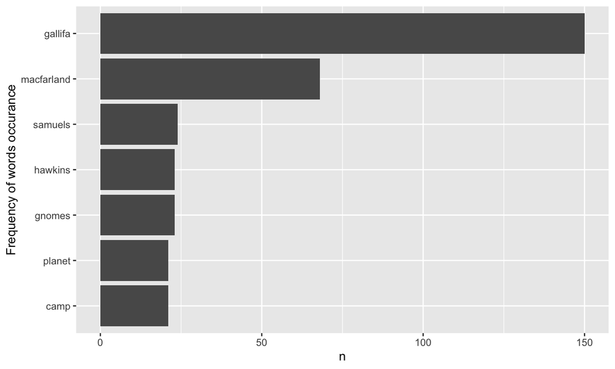

### book sites

http://freecomputerbooks.com/

https://en.wikisource.org/wiki/Main_Page

http://www.gutenberg.org/

## Text analysis links

[CRAN Task View: Natural Language Processing](https://cran.r-project.org/web/views/NaturalLanguageProcessing.html)

[RcmdrPlugin.temis: Graphical Integrated Text Mining Solution](https://cran.r-project.org/web/packages/RcmdrPlugin.temis/index.html)

[Text mining with R github](https://github.com/dgrtwo/tidy-text-mining)

r-break-corpus-into-sentences

[tokenizers](https://cran.r-project.org/web/packages/tokenizers/README.html)

[Introduction to the tokenizers Package](https://cran.r-project.org/web/packages/tokenizers/vignettes/introduction-to-tokenizers.html)

[Package ‘tokenizers’](https://cran.r-project.org/web/packages/tokenizers/tokenizers.pdf)